# 第1回 ガイダンス：Pythonの基本動作と、分析プロセスの全体像

明日、自転車を何台用意する？ データ解析を一周してみる

# 導入

## この授業で扱うこと

① この授業について●○○○○

- 全15回で、回帰 → 分類 → 教師なし学習を一通り扱う
- 題材は毎回ちがう分野の実データ（交通・住宅・医療・画像・社会経済・映画）
- 今日は、自転車シェアのデータで問いを立ててから答えるまでを一周する

## `fit()`一行で、結果は出る

① この授業について●●○○○

```python
model.fit(X, y)
```

- ライブラリを使えば、この一行で結果は出る
- では、なぜ中身まで学ぶのか？

## 中身を知らないと、直せない

① この授業について●●●○○

- 結果が正しいかどうか、判断できない
- うまくいかないとき、どこを直せばいいか分からない
- 間違った結果ほど、もっともらしい顔をして出てくる

## 1回の流れ

① この授業について●●●●○

1. 節の始めに、道筋の図で「いまどこか」を確かめる
2. スライドで、知りたいこと → コード → 結果 → 分かったこと、を一緒に読む
3. やってみよう：Colabで同じセルを実行し、同じ結果が出るか確かめる

動画の人は、「やってみよう」で一時停止して、ノートを実行してください。

## もう1つのねらい：表を扱う

① この授業について●●●●●

- pandasで、表を読み、列を選び、条件で絞り、まとめられるようになる
- 各節で、まずお手本のセルを実行し、読み方を確かめる
- セルは1行ずつより、役割・入力・出力のかたまりで読む

# 0. Colabを動かす

## 環境づくりは、なぜ大変？

0節 ① なぜColabか●○

- Pythonの道具（パッケージ）は、互いのバージョンに依存している
- Aを新しくしたらBが対応しておらず、インストールに失敗することはよくある
- だから実務や研究では、解析ごとに環境を分けて作る（コンテナや仮想環境）

## だから、この授業はColab

0節 ① なぜColabか●●

- 主要なパッケージが最初からそろった環境を、Googleが用意している
- ブラウザを開くだけで、全員が同じ環境になる
- 無料の範囲で使える。上限に達しても、勝手に課金されない

## Colab①：ノートを開く

0節 ② Colabの使い方●○○○

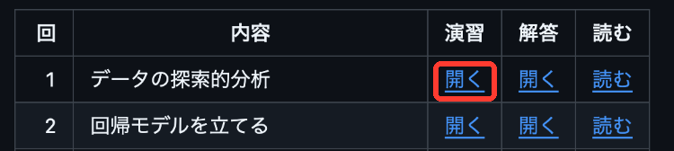

- 教材ページの表から、その回の「演習」列の［開く］をクリック
- 開いたノートは、そのまま実行して使う。ドライブへのコピーは要らない

## Colab②：セルを実行する

0節 ② Colabの使い方●●○○

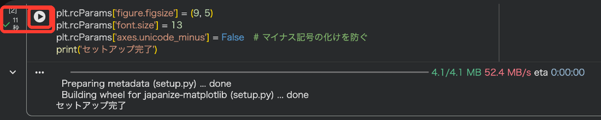

- コードのセルは、左の ▶ かShift + Enterで実行
- 結果がすぐ下に出て、終わると左に ✓ が付く

## プログラムは、上から下へ

0節 ② Colabの使い方●●●○

- セルの中は、上の行から順に実行される
- ノートも、上のセルから順に実行する。前のセルで作ったものを、後で使うから
- 迷ったら、いちばん上から実行し直す

## エラーは、いちばん下の行を読む

0節 ② Colabの使い方●●●●

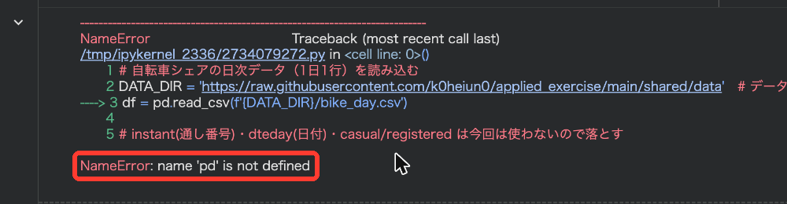

- NameError：上のセルを飛ばした
- ModuleNotFoundError：道具が入っていない／SyntaxError：打ち間違い

## やってみよう：0節

0節 ③ 確かめる●○

- 第1回のノートを開く
- 0節の「最初に実行する」のセルを ▶ で実行する

動画の人は、ここで一時停止。

## 答え合わせ：セットアップ完了

0節 ③ 確かめる●●

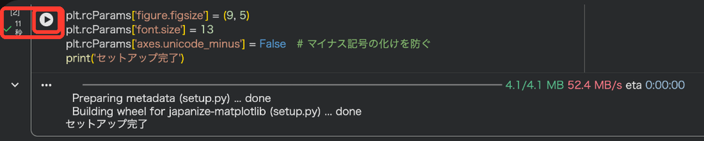

- 下に「セットアップ完了」が出ていればOK
- 赤いエラーが出たら、いちばん下の行を読んで、もう一度 ▶

# 明日、何台用意する？

## 場面：自転車シェア

② 場面●○○

- あなたは、自転車シェアの運営者
- 街のあちこちに自転車を置き、借りて乗り捨ててもらうサービス

## 決めたいこと

② 場面●●○

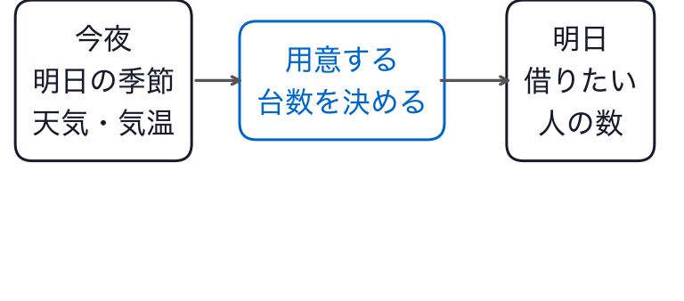

- 毎晩、明日の季節・天気・気温を見て、用意する台数を決めたい

## 足りなくても、余っても困る

② 場面●●●

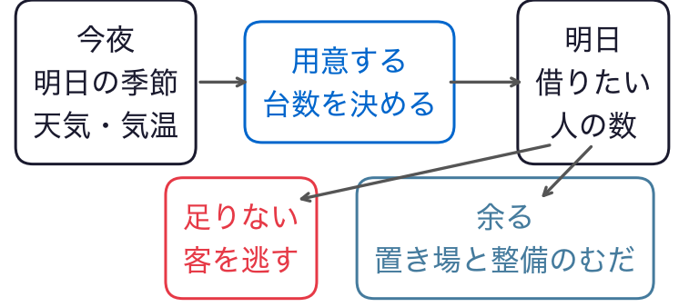

- 足りなければ客を逃し、余れば置き場と整備のむだになる

## 手元のデータ

③ 手元のデータ●○

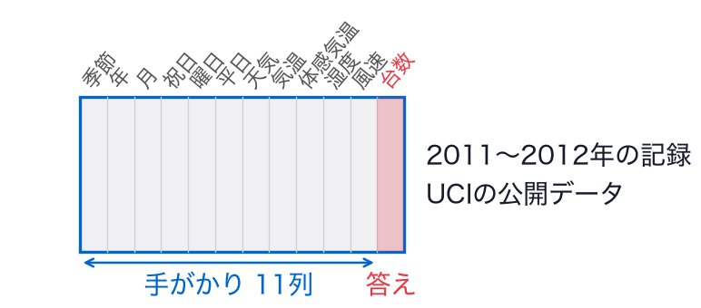

- 季節・天気・気温など11の手がかりと、答えの列`台数`（その日の利用台数）
- 1行が何を表すかは、1節で表を読んで確かめる

## データをのぞく

③ 手元のデータ●●

|  | 季節 | 年 | 月 | 天気 | 気温 | 台数 |
| --- | --- | --- | --- | --- | --- | --- |
| 0 | 1 | 0 | 1 | 2 | 0.344167 | 985 |
| 1 | 1 | 0 | 1 | 2 | 0.363478 | 801 |
| 2 | 1 | 0 | 1 | 1 | 0.196364 | 1349 |
| 3 | 1 | 0 | 1 | 1 | 0.200000 | 1562 |
| 4 | 1 | 0 | 1 | 1 | 0.226957 | 1600 |

- 季節（1〜4）、年（0が2011年）、月、天気（1が晴れ）、気温（0〜1に縮めた値）、台数

## 最後に出す答え

④ 今日の問い●○○

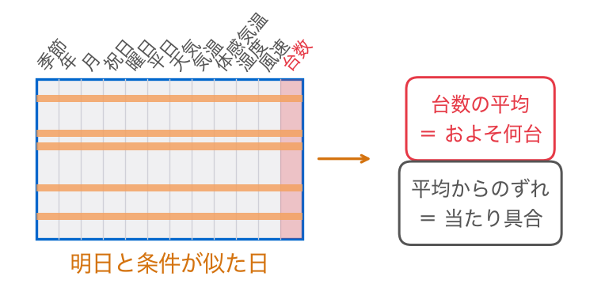

- 明日と条件が似た日の平均から出す「およそ何台」と、そのずれ

## 今日の問い

④ 今日の問い●●○

明日、自転車を何台用意すればいいか。

最後に、数字で答えます。

## 今日の道筋

④ 今日の問い●●●

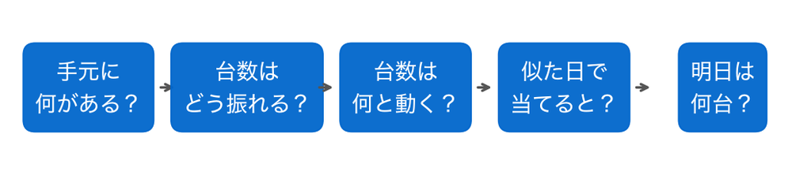

- 5つの小さな問いに順に答えて、明日の台数にたどり着く
- 節の始めに、この図で「いまどこか」を確かめる

# 1. どんなデータが手元にある？

## まず、手元のデータを知る

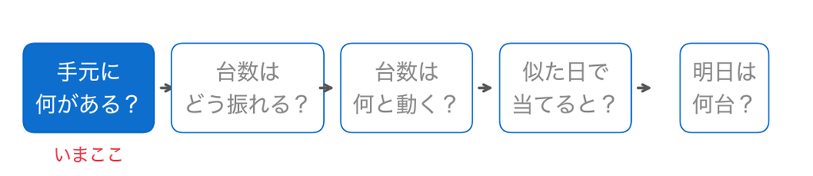

- 答える前に、表を読み込んで中身を見る

## 確かめたいのは3つ

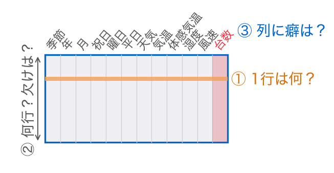

- 1行は何か。何行あって、欠けはないか。列に、扱いに困る癖はないか

## お手本：表を読み込む

1節 ① 1行は何か●○○

```python
# データはこのリポジトリから読み込む
DATA_DIR = ('https://raw.githubusercontent.com/k0heiun0/'
            'applied_exercise_preview/main/shared/data')
df = pd.read_csv(f'{DATA_DIR}/bike_day.csv')
df = df.drop(columns=['instant', 'dteday', 'casual', 'registered'])
df.head()
```

- 役割：表を読み込み、使わない列を落として、先頭5行を見る
- 入力：データの置き場所とファイル名
- 出力：表`df`（このあと全部の節で使う）

## `df =`は、名前にしまう

1節 ① 1行は何か●●○

```python
# データはこのリポジトリから読み込む
DATA_DIR = ('https://raw.githubusercontent.com/k0heiun0/'
            'applied_exercise_preview/main/shared/data')
df = pd.read_csv(f'{DATA_DIR}/bike_day.csv')
df = df.drop(columns=['instant', 'dteday', 'casual', 'registered'])
df.head()
```

- 右で読んだ表を、左の名前`df`にしまう。これが変数
- `pd.read_csv`は「pandasのread_csv」という関数
- `df.head()`のように`df.`に続けて書くのは、表が持つ機能（メソッド）

## 1行が1日

1節 ① 1行は何か●●●

|  | season | yr | mnth | holiday | weekday | workingday | weathersit | temp | atemp | hum | windspeed | cnt |
| --- | --- | --- | --- | --- | --- | --- | --- | --- | --- | --- | --- | --- |
| 0 | 1 | 0 | 1 | 0 | 6 | 0 | 2 | 0.344167 | 0.363625 | 0.805833 | 0.160446 | 985 |
| 1 | 1 | 0 | 1 | 0 | 0 | 0 | 2 | 0.363478 | 0.353739 | 0.696087 | 0.248539 | 801 |
| 2 | 1 | 0 | 1 | 0 | 1 | 1 | 1 | 0.196364 | 0.189405 | 0.437273 | 0.248309 | 1349 |
| 3 | 1 | 0 | 1 | 0 | 2 | 1 | 1 | 0.200000 | 0.212122 | 0.590435 | 0.160296 | 1562 |
| 4 | 1 | 0 | 1 | 0 | 3 | 1 | 1 | 0.226957 | 0.229270 | 0.436957 | 0.186900 | 1600 |

- 1行が1日の記録。当てたいのは最後の列のcnt（その日の利用台数）

## 列名が、読みにくい

1節 ② 列名を日本語に●○○○

|  | season | yr | mnth | holiday | weekday | workingday | weathersit | temp | atemp | hum | windspeed | cnt |
| --- | --- | --- | --- | --- | --- | --- | --- | --- | --- | --- | --- | --- |
| 0 | 1 | 0 | 1 | 0 | 6 | 0 | 2 | 0.344167 | 0.363625 | 0.805833 | 0.160446 | 985 |
| 1 | 1 | 0 | 1 | 0 | 0 | 0 | 2 | 0.363478 | 0.353739 | 0.696087 | 0.248539 | 801 |
| 2 | 1 | 0 | 1 | 0 | 1 | 1 | 1 | 0.196364 | 0.189405 | 0.437273 | 0.248309 | 1349 |
| 3 | 1 | 0 | 1 | 0 | 2 | 1 | 1 | 0.200000 | 0.212122 | 0.590435 | 0.160296 | 1562 |
| 4 | 1 | 0 | 1 | 0 | 3 | 1 | 1 | 0.226957 | 0.229270 | 0.436957 | 0.186900 | 1600 |

- season・yr・mnth・cnt……英語の略称で、何の列かすぐには読めない
- 前処理として、列名を日本語に付け替えてから使う

## お手本：列名を日本語にする

1節 ② 列名を日本語に●●○○

```python
ja_names = {'season': '季節', 'yr': '年', 'mnth': '月',
            'holiday': '祝日', 'weekday': '曜日',
            'workingday': '平日', 'weathersit': '天気',
            'temp': '気温', 'atemp': '体感気温', 'hum': '湿度',
            'windspeed': '風速', 'cnt': '台数'}
df = df.rename(columns=ja_names)
df.head()
```

- 役割：英語の列名を日本語に付け替え、先頭5行を見る
- 入力：表`df` 出力：列名が日本語になった表`df`

## `{ }`は、名前の対応表

1節 ② 列名を日本語に●●●○

```python
ja_names = {'season': '季節', 'yr': '年', 'mnth': '月',
```

- `{'元の名前': '新しい名前', ...}`と組を並べたもの。辞書と呼ぶ
- `rename(columns=ja_names)`で、この対応どおりに列名を付け替える
- 値は変わらない。変わるのは列名だけ

## 列名が、日本語になった

1節 ② 列名を日本語に●●●●

|  | 季節 | 年 | 月 | 祝日 | 曜日 | 平日 | 天気 | 気温 | 体感気温 | 湿度 | 風速 | 台数 |
| --- | --- | --- | --- | --- | --- | --- | --- | --- | --- | --- | --- | --- |
| 0 | 1 | 0 | 1 | 0 | 6 | 0 | 2 | 0.344167 | 0.363625 | 0.805833 | 0.160446 | 985 |
| 1 | 1 | 0 | 1 | 0 | 0 | 0 | 2 | 0.363478 | 0.353739 | 0.696087 | 0.248539 | 801 |
| 2 | 1 | 0 | 1 | 0 | 1 | 1 | 1 | 0.196364 | 0.189405 | 0.437273 | 0.248309 | 1349 |
| 3 | 1 | 0 | 1 | 0 | 2 | 1 | 1 | 0.200000 | 0.212122 | 0.590435 | 0.160296 | 1562 |
| 4 | 1 | 0 | 1 | 0 | 3 | 1 | 1 | 0.226957 | 0.229270 | 0.436957 | 0.186900 | 1600 |

- ここから先は、季節・気温・台数といった日本語の名前で列を選ぶ

## 変えてみる：表の大きさを見る

1節 ③ 何行、欠けは●○○○

```python
print(df.shape)       # (行の数, 列の数)
print(df.shape[0])    # 行の数だけ。[0] は「1つ目」
```

- `head()`は先頭だけ。表全体の大きさは`shape`で分かる
- `shape`は表が持っている値なので、`()`を付けない

## 731日ぶん

1節 ③ 何行、欠けは●●○○

```
(731, 12)
731
```

- 731行×12列。2年ぶんの毎日が、1日も欠けずに並ぶ

## 変えてみる：欠けた値を数える

1節 ③ 何行、欠けは●●●○

```python
df.isnull().sum()          # 列ごとに、欠けた値の数
```

- `isnull()`は、各マスが欠けているかをTrue/Falseで表す
- `sum()`で、列ごとにTrueの数を数える

## 欠けた値は、ない

1節 ③ 何行、欠けは●●●●

```
季節      0
年       0
月       0
祝日      0
曜日      0
平日      0
天気      0
気温      0
体感気温    0
湿度      0
風速      0
台数      0
```

- どの列も0。このデータに欠けた値はない（実務では普通にある）

## 変えてみる：要約で、列の癖を探す

1節 ④ 列の癖●○○

```python
df.describe().round(2)     # 全部の列を、数行の要約に
```

- `describe()`は、列ごとの平均・ばらつき・最小・最大などを並べる
- 数字を眺めて、「あれ？」と思う列を探す

## TODO①：気になる列を挙げる

1節 ④ 列の癖●●○

```python
# TODO: describe() の出力で、気になる列とその理由をコメントに書く
# ヒント1: 気温と体感気温の平均・ばらつきを見比べてみよう
# ヒント2: 季節や天気の数字の大小に、意味はある？
...
```

- `...`が、あなたが書く場所。ここではコメントを書くだけ

## TODOの書き方

1節 ④ 列の癖●●●

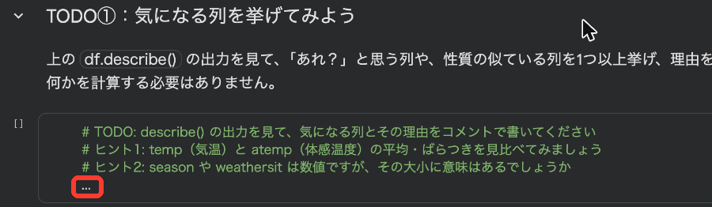

- 何を書くかはセルの前の文章に、手がかりは「ヒント」にある
- 動かないときは［ランタイム］→［再起動］→［すべてのセルを実行］

## やってみよう：1節とTODO①

1節 ⑤ 確かめる●○○○○○

- 1節のセルを上から実行し、ここまでと同じ表と数が出るか確かめる
- TODO①：`describe`の出力から、気になる列を挙げる

動画の人は、ここで一時停止。

## 気温と体感気温を見比べると？

1節 ⑤ 確かめる●●○○○○

|  | 季節 | 天気 | 気温 | 体感気温 |
| --- | --- | --- | --- | --- |
| count | 731.00 | 731.00 | 731.00 | 731.00 |
| mean | 2.50 | 1.40 | 0.50 | 0.47 |
| std | 1.11 | 0.54 | 0.18 | 0.16 |
| min | 1.00 | 1.00 | 0.06 | 0.08 |
| 25% | 2.00 | 1.00 | 0.34 | 0.34 |
| 50% | 3.00 | 1.00 | 0.50 | 0.49 |
| 75% | 3.00 | 2.00 | 0.66 | 0.61 |
| max | 4.00 | 3.00 | 0.86 | 0.84 |

- 要約から4列を抜き出した。気温と体感気温は？

## 実は、ほぼ同じ2列

1節 ⑤ 確かめる●●●○○○

|  | 季節 | 天気 | 気温 | 体感気温 |
| --- | --- | --- | --- | --- |
| count | 731.00 | 731.00 | 731.00 | 731.00 |
| mean | 2.50 | 1.40 | 0.50 | 0.47 |
| std | 1.11 | 0.54 | 0.18 | 0.16 |
| min | 1.00 | 1.00 | 0.06 | 0.08 |
| 25% | 2.00 | 1.00 | 0.34 | 0.34 |
| 50% | 3.00 | 1.00 | 0.50 | 0.49 |
| 75% | 3.00 | 2.00 | 0.66 | 0.61 |
| max | 4.00 | 3.00 | 0.86 | 0.84 |

- 平均0.50と0.47、ばらつき（std）0.18と0.16。ほぼ同じ

## 季節の数字に、意味はある？

1節 ⑤ 確かめる●●●●○○

|  | 季節 | 天気 | 気温 | 体感気温 |
| --- | --- | --- | --- | --- |
| count | 731.00 | 731.00 | 731.00 | 731.00 |
| mean | 2.50 | 1.40 | 0.50 | 0.47 |
| std | 1.11 | 0.54 | 0.18 | 0.16 |
| min | 1.00 | 1.00 | 0.06 | 0.08 |
| 25% | 2.00 | 1.00 | 0.34 | 0.34 |
| 50% | 3.00 | 1.00 | 0.50 | 0.49 |
| 75% | 3.00 | 2.00 | 0.66 | 0.61 |
| max | 4.00 | 3.00 | 0.86 | 0.84 |

- 季節は1〜4、天気は1〜3の数字

## 実は、区分に付けた番号

1節 ⑤ 確かめる●●●●●○

|  | 季節 | 天気 | 気温 | 体感気温 |
| --- | --- | --- | --- | --- |
| count | 731.00 | 731.00 | 731.00 | 731.00 |
| mean | 2.50 | 1.40 | 0.50 | 0.47 |
| std | 1.11 | 0.54 | 0.18 | 0.16 |
| min | 1.00 | 1.00 | 0.06 | 0.08 |
| 25% | 2.00 | 1.00 | 0.34 | 0.34 |
| 50% | 3.00 | 1.00 | 0.50 | 0.49 |
| 75% | 3.00 | 2.00 | 0.66 | 0.61 |
| max | 4.00 | 3.00 | 0.86 | 0.84 |

- 季節=4は季節=1の4倍ではない。区分の番号にすぎない
- 天気は1晴れ→3雨・雪の順だが、間隔に意味はない

## 答え合わせ：TODO①の例

1節 ⑤ 確かめる●●●●●●

- `気温`と`体感気温`は、平均もばらつきもほぼ同じ2列
- `季節`は区分の番号、`天気`は順だけを表す番号
- この2つの癖をコメントに書けていればOK

# 2. 1日の台数は、どれくらい振れる？

## 表は分かった。次は台数の振れ

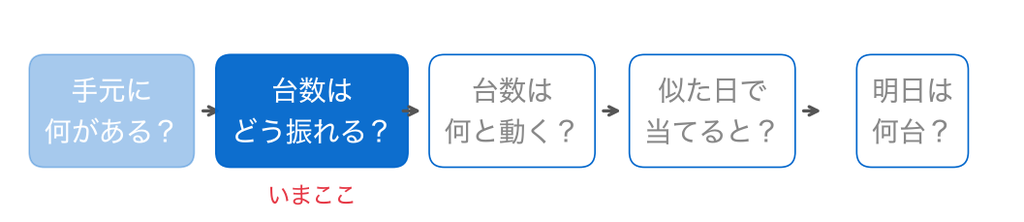

- 当てる前に、当てたい台数そのものを見ておく

## 毎日、同じ台数でいい？

2節 ① 平均と最少・最多●○○○○○

- 1日の台数がほとんど振れないなら、毎日同じ台数を用意すれば済む
- 確かめるには、平均と、いちばん少ない日・多い日を出せばよい

## 列を1本取り出し、数個の数に

2節 ① 平均と最少・最多●●○○○○

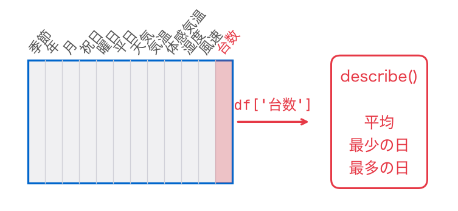

- 台数の列だけを取り出し、`describe()`で平均・最少・最多などにまとめる

## お手本：台数の列だけを要約する

2節 ① 平均と最少・最多●●●○○○

```python
df['台数'].describe().round(1)
```

- 役割：台数の列だけを取り出し、平均やばらつきにまとめる
- `df['台数']`のように`[ ]`に列名を入れると、その列だけを取り出せる
- `describe()`は、1節と同じ要約。今度は台数の列だけにかける

## 平均は4504台

2節 ① 平均と最少・最多●●●●○○

```
count     731.0
mean     4504.3
std      1937.2
min        22.0
25%      3152.0
50%      4548.0
75%      5956.0
max      8714.0
```

- 平均（mean）は4504台
- $i$日目の台数を$y_i$、日数を$n$とすると、平均は $\bar{y} = \frac{1}{n}\sum_{i=1}^{n} y_i$

## 最少22台、最多8714台

2節 ① 平均と最少・最多●●●●●○

```
count     731.0
mean     4504.3
std      1937.2
min        22.0
25%      3152.0
50%      4548.0
75%      5956.0
max      8714.0
```

- いちばん少ない日（min）は22台、いちばん多い日（max）は8714台

## 毎日同じでは、過不足が出る

2節 ① 平均と最少・最多●●●●●●

## 端の日は、まれな1日？

2節 ② 散らばりの形●○○○

- 22台や8714台は、たまたまの1日だけかもしれない
- 間の日がどう散らばるかは、数字の要約では見えない
- 図にして確かめる

## お手本：台数のヒストグラム

2節 ② 散らばりの形●●○○

```python
plt.hist(df['台数'], bins=40, color='#0066cc', edgecolor='white')
plt.xlabel('1日の利用台数 台数')
plt.ylabel('日数')
plt.show()
```

- 役割：台数を区間に分け、各区間に何日あったかを棒で描く
- `bins=40`は、区間の数

## 横が台数、縦が日数

2節 ② 散らばりの形●●●○

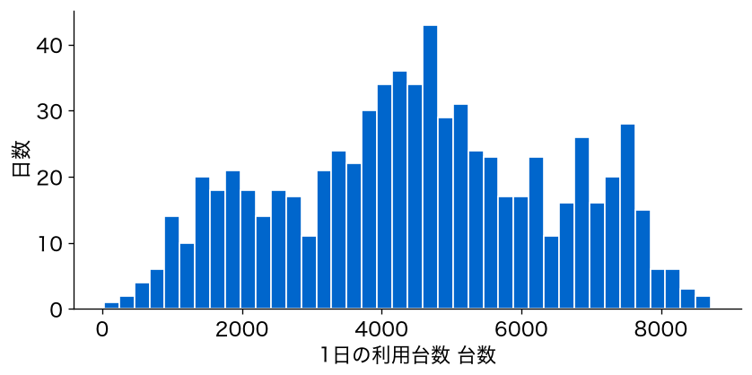

- 棒の高さが、その台数だった日数

## 少ない日も多い日も、何十日もある

2節 ② 散らばりの形●●●●

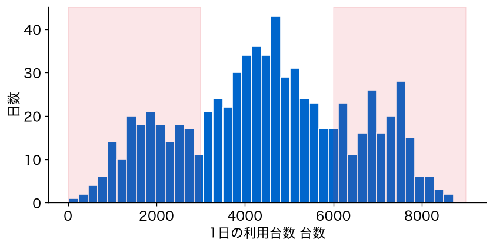

- 3000台未満が172日、6000台より多い日が180日。端の日はまれではない

## やってみよう：2節

2節 ③ 確かめる●○

- 2節のお手本の2つのセルを実行する
- ここまでと同じ要約と図が出るか確かめる

動画の人は、ここで一時停止。

## 振れは、本物

2節 ③ 確かめる●●

- 足りない日も余る日も、何十日も出る。多い日と少ない日は、何が違う？

# 3. 台数は、何と一緒に動く？

## 多い日と少ない日は、何が違う？

- 手がかりの列と台数を、1枚の図に重ねて見る

## まず、気温と台数

3節 ① 気温と台数●○○○○

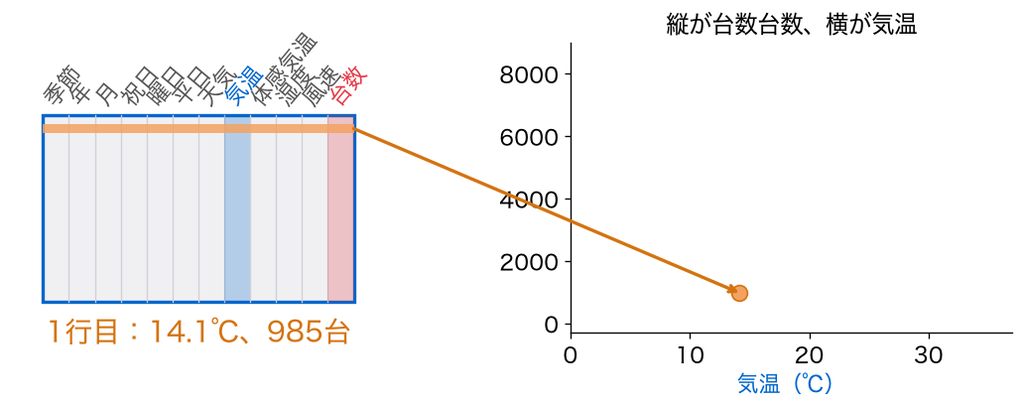

- 1行（1日）を、横が気温、縦が台数の1つの点にする
- 暖かい日ほど多いなら、点は右上がりに並ぶはず

## お手本：気温と台数の散布図

3節 ① 気温と台数●●○○○

```python
plt.scatter(df['気温'] * 41, df['台数'], s=8, alpha=0.3)
plt.xlabel('気温（℃）')
plt.ylabel('利用台数 台数')
plt.show()
```

- `plt.scatter(横, 縦)`は、1日を1つの点にして描く
- `気温`は0〜1に縮めた値。41を掛けて℃に戻す

## 暖かいほど、多い

3節 ① 気温と台数●●●○○

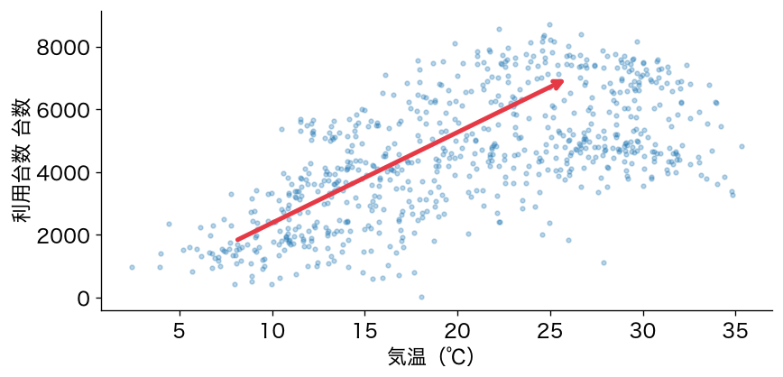

- 全体として右上がり。暖かい日ほど、台数が多い

## でも、いちばん暑いあたりは？

3節 ① 気温と台数●●●●○

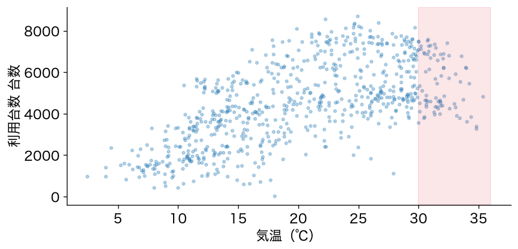

- 30℃を超えたあたりを見てほしい

## 暑すぎると、頭打ち

3節 ① 気温と台数●●●●●

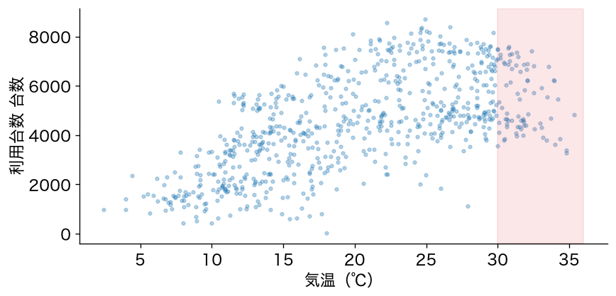

- 伸びが止まり、少し下がっている。関係は右上がりでも、一直線とは限らない

## 季節でも、描いてみる

3節 ② 季節と台数●○○○

- 1節で、季節は区分の番号だと見た
- 番号の列を散布図にすると、どう見えるか？

## 変えてみる：季節と台数

3節 ② 季節と台数●●○○

```python
plt.scatter(df['季節'], df['台数'], s=8, alpha=0.3)
plt.xlabel('季節（区分の番号）')
plt.ylabel('利用台数 台数')
plt.show()
```

- お手本の`df['気温'] * 41`を、`df['季節']`に変えるだけ

## 点が、4本の縦の帯に

3節 ② 季節と台数●●●○

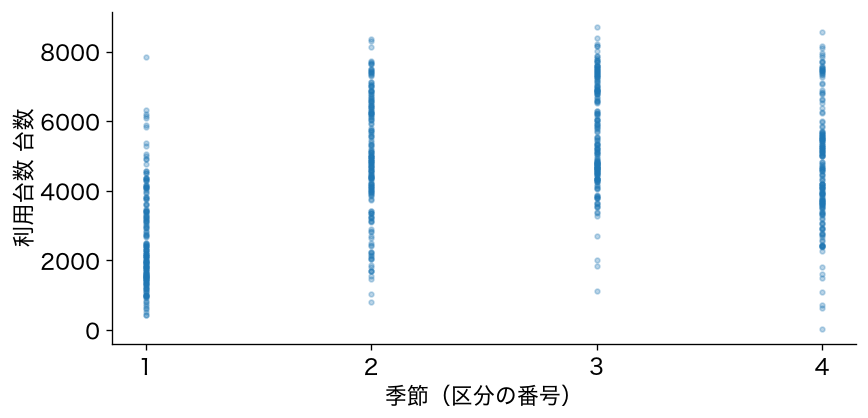

- 横の値が1〜4しかないので、点は4本の帯に並ぶ

## 帯ごとに、高さが違う

3節 ② 季節と台数●●●●

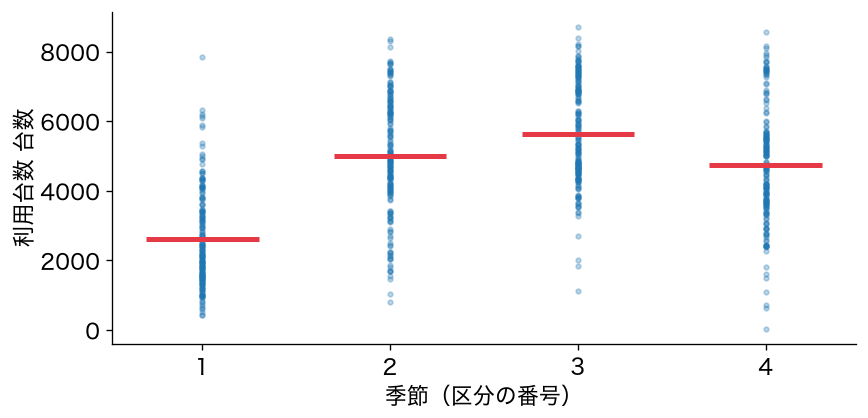

- 赤い線が帯ごとの平均。1の帯だけが2604台と低い
- 番号の大小ではなく、帯ごとの高さを比べればよい

## TODO②：好きな列で散布図を描く

3節 ③ 確かめる●○○○○○○

```python
# TODO: 年・月・天気・湿度・風速から
#       1つ選び、台数との散布図を描く
# ヒント: 上のセルの df['季節'] を df['選んだ列'] に変える
...
```

- すぐ上のセルを、1か所だけ変えれば書ける

## やってみよう：3節とTODO②

3節 ③ 確かめる●●○○○○○

- 3節のお手本と「変えてみる」のセルを実行する
- TODO②：好きな列を選び、`台数`との散布図を描く。帯になる？傾く？

動画の人は、ここで一時停止。

## 答え合わせ：TODO②の例

3節 ③ 確かめる●●●○○○○

```python
plt.scatter(df['湿度'], df['台数'], s=8, alpha=0.3)
plt.xlabel('湿度（0〜1）')
plt.ylabel('利用台数 台数')
plt.show()
```

- 湿度を選んだ例。`df['季節']`を`df['湿度']`に変えた

## 湿度と台数は、どんな関係？

3節 ③ 確かめる●●●●○○○

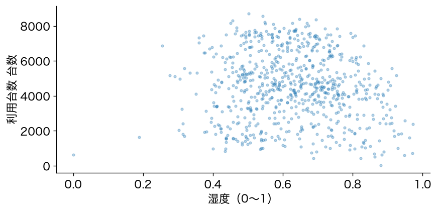

- 気温のような、はっきりした右上がりは見えない

## 右端だけ、少ない？

3節 ③ 確かめる●●●●●○○

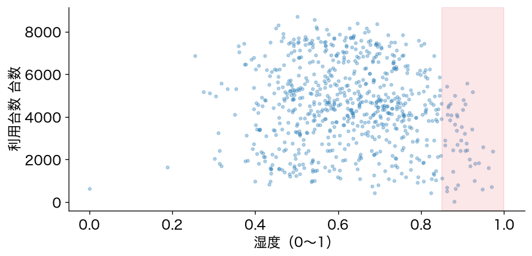

- 湿度0.85以上のあたりは、点が下に寄っている

## 右端の日を取り出す

3節 ③ 確かめる●●●●●●○

```
湿度0.85以上 日数: 46  平均台数: 2849
それ以外     日数: 685  平均台数: 4616
天気
2    29
3    17
```

- 46日で平均2849台。ほかの日の4616台より少ない

## 右端は、曇りか雨・雪の日

3節 ③ 確かめる●●●●●●●

```
湿度0.85以上 日数: 46  平均台数: 2849
それ以外     日数: 685  平均台数: 4616
天気
2    29
3    17
```

- 46日のうち、曇り（2）が29日、雨・雪（3）が17日。晴れの日は1日もない
- 少ないのは、湿度より天気のせいかもしれない

# 4. 暑い日と寒い日で、台数は違う？

## 図で見えたことを、数字で確かめる

- 散布図では、暖かい日ほど台数が多かった。これを数字で言いたい

## 暑い日だけを取り出す

4節 ① 暑い日を取り出す●○○○○

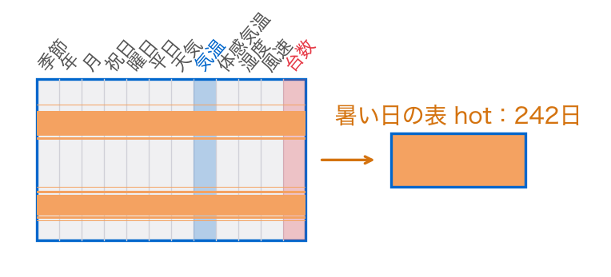

- 塗った25℃以上の日の平均が、全体の4504台より多いかを見る

## お手本：条件で行を絞る

4節 ① 暑い日を取り出す●●○○○

```python
hot = df[df['気温'] * 41 >= 25]     # 25度以上の日だけ
print('日数:', len(hot))
print('平均台数:', round(hot['台数'].mean()))
```

- 役割：25℃以上の日だけを取り出し、日数と平均台数を出す
- 入力：表`df` 出力：暑い日だけの表`hot`

## `[ ]`に、True/Falseの並び

4節 ① 暑い日を取り出す●●●○○

```
       気温  25以上か
112  18.9  False
113  23.8  False
114  24.9  False
115  25.9   True
116  25.4   True
```

- `df['気温'] * 41 >= 25`は、1日ごとの「25℃以上か」の並び
- 左の数字は行の番号。115・116の日だけがTrue

## Trueの行だけが、残る

4節 ① 暑い日を取り出す●●●●○

```
       気温  25以上か
112  18.9  False
113  23.8  False
114  24.9  False
115  25.9   True
116  25.4   True

hot に残った行: [115, 116]
```

- `df[ ]`にTrue/Falseの並びを入れると、Trueの行だけが残る
- 残った表が`hot`。暑い日だけの表になる

## 暑い日は、1000台以上多い

4節 ① 暑い日を取り出す●●●●●

```
日数: 242
平均台数: 5632
```

- 25℃以上の日は242日、平均5632台。全体の平均4504台より1000台以上多い

## 変えてみる：寒い日と比べる

4節 ② 寒い日と比べる●○

```python
cold = df[df['気温'] * 41 < 10]     # 10度未満の日だけ
print('日数:', len(cold))
print('平均台数:', round(cold['台数'].mean()))
```

- 条件の`>= 25`を`< 10`に変えるだけ

## 寒い日は、3分の1もない

4節 ② 寒い日と比べる●●

```
日数: 60
平均台数: 1678
```

- 10℃未満の日は60日、平均1678台。暑い日の3分の1もない

## 同じ暑い日でも、年で違う？

4節 ③ 条件を重ねる●○○○

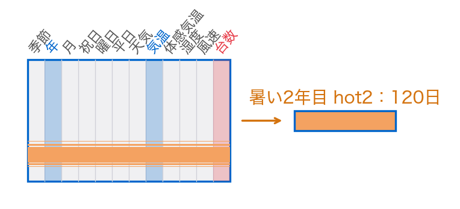

- 25℃以上で、しかも2年目（2012年）の日だけを取り出してみる

## 変えてみる：条件を2つ重ねる

4節 ③ 条件を重ねる●●○○

```python
# 25度以上 かつ 2年目
hot2 = df[(df['気温'] * 41 >= 25) & (df['年'] == 1)]
print('日数:', len(hot2))
print('平均台数:', round(hot2['台数'].mean()))
```

- `&`は「かつ」。それぞれの条件を`( )`で囲む
- `==`は「等しいか」を調べる記号。`=`（名前にしまう）とは別物

## 暑い2年目は、さらに多い

4節 ③ 条件を重ねる●●●○

```
日数: 120
平均台数: 6741
```

- 120日、平均6741台。同じ暑い日でも、2年目のほうがさらに多い

## 手がかりは、1つとは限らない

4節 ③ 条件を重ねる●●●●

```
日数: 120
平均台数: 6741
```

- 気温だけでなく、年も台数に関係していそう

## TODO③：天気で比べる

4節 ④ 確かめる●○○○

```python
# TODO: 晴れの日（天気 == 1）と雨・雪の日（== 3）で、
#       日数と平均台数を表示する
# ヒント: お手本の条件を、df['天気'] == 1 に変えればよい
...
```

- お手本を2回、条件だけ変えて使う

## やってみよう：4節とTODO③

4節 ④ 確かめる●●○○

- 4節のセルを実行し、ここまでと同じ日数と平均が出るか確かめる
- TODO③：晴れの日と雨・雪の日で、日数と平均台数を比べる

動画の人は、ここで一時停止。

## 答え合わせ：TODO③

4節 ④ 確かめる●●●○

```
天気 1  日数: 463  平均台数: 4877
天気 3  日数: 21  平均台数: 1803
```

- 晴れは4877台、雨・雪は1803台。天気も台数に関係している

## でも、雨・雪の日は21日だけ

4節 ④ 確かめる●●●●

```
天気 1  日数: 463  平均台数: 4877
天気 3  日数: 21  平均台数: 1803
```

- 日数が少ないグループの平均は、頼りない。日数も一緒に見る

# 5. どれがいちばん効きそう？

## 手がかりは、どれが強い？

- 気温・年・天気が見えた。でも列は11本。全部の散布図を見比べるのは大変

## 相関係数

5節 ① 相関で順位を付ける●○○○○○

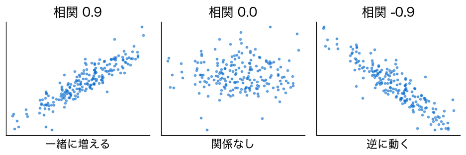

- 2つの列が一緒に動く度合いを、−1〜1の1つの数にしたもの（図は作った例）

## 相関係数を、式で書く

5節 ① 相関で順位を付ける●●○○○○

$$r = \frac{\sum_i (x_i - \bar{x})(y_i - \bar{y})}{\sqrt{\sum_i (x_i - \bar{x})^2}\,\sqrt{\sum_i (y_i - \bar{y})^2}}$$

- そろって平均より上（または下）の日が多いほど、分子は大きな正の数
- 分母で割って、−1〜1の範囲におさめている

## 台数との相関を、強い順に並べたい

5節 ① 相関で順位を付ける●●●○○○

- 11本の列それぞれと`台数`の相関係数を出し、大きい順に並べる
- 上位に来る列が、台数と一緒に動く手がかりの候補

## お手本：台数との相関を、強い順に

5節 ① 相関で順位を付ける●●●●○○

```python
corr = df.corr(numeric_only=True)['台数'].drop('台数')
corr.sort_values(ascending=False).round(2)
```

- `corr`で全部の組み合わせの相関 → `['台数']`の列を取り出す
- `drop('台数')`で自分自身を外し、`sort_values`で大きい順に並べる

## 上位は、気温と年

5節 ① 相関で順位を付ける●●●●●○

```
体感気温    0.63
気温      0.63
年       0.57
季節      0.41
月       0.28
曜日      0.07
平日      0.06
祝日     -0.07
湿度     -0.10
風速     -0.23
天気     -0.30
```

- 上位は体感気温・気温（0.63）、年（0.57）

## 4節で見た手がかりが、並んでいる

5節 ① 相関で順位を付ける●●●●●●

```
体感気温    0.63
気温      0.63
年       0.57
季節      0.41
月       0.28
曜日      0.07
平日      0.06
祝日     -0.07
湿度     -0.10
風速     -0.23
天気     -0.30
```

- 天気は −0.30。逆向きでは、いちばん強い

## 変えてみる：そっくりな2列の相関

5節 ② そっくりな2列●○

```python
round(df['気温'].corr(df['体感気温']), 3)
```

- 列`.corr(`別の列`)`で、2列だけの相関係数が出る
- TODO①で「ほぼ同じ」と見た、気温と体感気温を比べる

## ほぼ1。ほぼ同じ列

5節 ② そっくりな2列●●

```
0.992
```

- 気温と体感気温の相関は0.992
- 2列を両方とも手がかりに使うと、どちらの列の影響か決めきれない

## やってみよう：5節

5節 ③ 確かめる●

- 5節のお手本と「変えてみる」のセルを実行する
- ここまでと同じ並びと数が出るか確かめる

動画の人は、ここで一時停止。

## 「気温が原因」と言える？

5節 ④ 相関と因果●○○

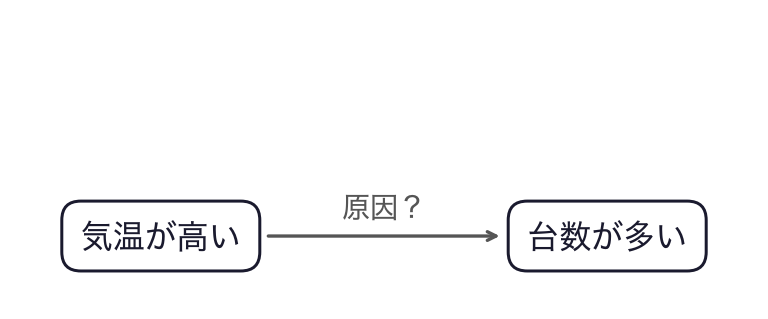

- 気温と台数の相関は0.63。気温が高いことが原因で、台数が増えるのか？

## 季節が、両方を動かす

5節 ④ 相関と因果●●○

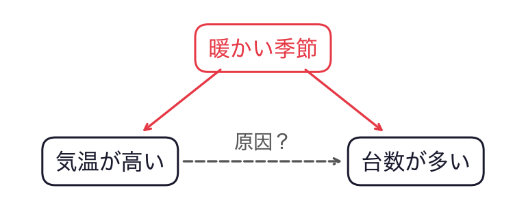

- 暖かい季節は気温が高く、出かける人も多い。共通の原因がある（交絡）

## 相関は、下見

5節 ④ 相関と因果●●●

相関は、どの手がかりを疑うべきかの下見。因果の証明ではありません。

# 6. 似た日の平均で当てる

## 手がかりは見えた。どう当てる？

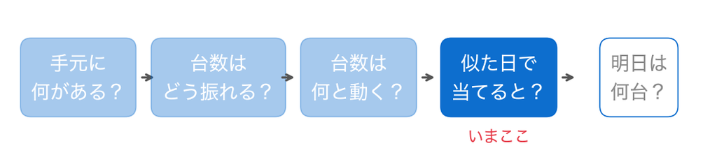

- 気温・年・天気を使って、台数を当てる

## 問いを、答えられる形に

6節 ① 基準を置く●○○○○○

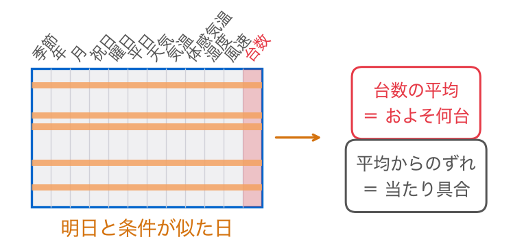

- 答える式はまだない。でも、似た日の平均なら4節と同じく計算できる

## 外れ幅の平均

6節 ① 基準を置く●●○○○○

## 外れ幅の平均を、式で書く

6節 ① 基準を置く●●●○○○

$$\text{外れ幅の平均} = \frac{1}{n}\sum_{i=1}^{n} \bigl|\,y_i - \hat{y}_i\,\bigr|$$

- $\hat{y}_i$（ワイ・ハット）は$i$日目の答え。$|\ |$は符号を外して大きさだけにする
- 毎日、全体の平均と答えるなら $\hat{y}_i = \bar{y}$

## まず、何も考えずに答える

6節 ① 基準を置く●●●●○○

- 毎日「全体の平均」と答えたら、外れ幅の平均はいくつか
- これを基準にして、手がかりでどこまで縮むかを見る

## お手本：毎日、全体の平均と答える

6節 ① 基準を置く●●●●●○

```python
pred = df['台数'].mean()     # 答え：毎日、全体の平均
print('答え:', round(pred), '台')
print('外れ幅の平均:', round((df['台数'] - pred).abs().mean()), '台')
```

- `df['台数'] - pred`で毎日の差、`abs()`で大きさだけにし、`mean()`で平均

## 基準は、1582台

6節 ① 基準を置く●●●●●●

```
答え: 4504 台
外れ幅の平均: 1582 台
```

- 毎日4504台と答えると、平均して1582台外れる